# R Notebook

Phylum relative abundance analyses

Notes: * Enrico advised binomial model because im dealing with proportions.

- Binomial model expects 2 column response variable of successes vs failures. Which in my case will be number of proteobacteria detected vs number of other bacteria detected. Specifically to my dataframe this will be “Abundance” vs “Abundance - NumberOfReads”.
- According to Zuur book could also model w/ response as simple relative abundance as in other models. BUT Enrico says if this method used, i would have to account for sample depth somehow.
- See Gillingham flamingo paper for similar analysis

# Data cleaning

Scale and centring numeric predictors

```r
#removed "QubitDNA"
numeric.predictors <- c("Tarsus","Weight", "wing", "broodSizeWhenSampled", "broodSizeMax", "totalFledge", "clutchSize", "layDateFirst", "numberDeadPreRinged", "numberDeadPostRinged","scaled.mass","scaled.mass.wing.adult", "scaled.mass.tarsus.adult","scaled.mass.chick", "scaled.mass.tarsus", "scaled.mass.wing", "DistanceToEdge")

# centre and scale numeric variables ie. subtract mean and divide by st. deviation
metadata.scaled <- metadata
metadata.scaled[,numeric.predictors] <- scale(metadata.scaled[,numeric.predictors])

adults.meta.scaled <- adults.meta
adults.meta.scaled[,numeric.predictors] <- scale(adults.meta.scaled[,numeric.predictors])
#
# nestlings.meta.scaled <- nestlings.meta
# nestlings.meta.scaled[,numeric.predictors] <- scale(nestlings.meta.scaled[,numeric.predictors])
```

# Relative abundance graph

Mean relative abundance and SE *rename variables here to differentiate from variables in next chunk*

```r
# phylo.glom <-  tax_glom(phylo.spring, "Phylum", NArm = TRUE)  # fast, <2mins
# ## transform to relative abundances
# phylo.glom.ra <- transform_sample_counts(phylo.glom, function(x){x / sum(x)}) # uncomment to convert to relative abundance
#
# mot <- psmelt(phylo.glom.ra)
# # calc standard error
# se <- function(x) sqrt(var(x)/length(x))
#
# mot %>%
#   group_by(Phylum) %>%
#   summarise_at(vars(Abundance), funs(mean, se))%>%
#   arrange(-mean)%>%
#   mutate_if(is.numeric, round, 3)
```

Create abundance column w/o converting to relative abundance.

```r
# sample_data(phylo.spring) <- metadata.scaled
# phyla.glom.scaled <-  tax_glom(phylo.spring, "Phylum", NArm = TRUE)
# melted.p.glom.scaled <- psmelt(phyla.glom.scaled)
#
# saveRDS(phyla.glom.scaled, "../Data/05_phyla.glom.scaled.rds")
# saveRDS(melted.p.glom.scaled, "../Data/05_melted.p.glom.scaled.rds")
```

Read in melted and scaled metadata with abundance (absolute rather than relative abundance)

```r
#phyla.glom.scaled <- readRDS("../Data/05_phyla.glom.scaled.rds")
mot <- readRDS("../Data/05_melted.p.glom.scaled.rds")
```

```r
proteobacteria.df <- mot[mot$Phylum=="Proteobacteria",]
firmicutes.df <- mot[mot$Phylum=="Firmicutes",]
# tenericutes.df <- mot[mot$Phylum=="Tenericutes",]
# bacteroidetes.df <- mot[mot$Phylum=="Bacteroidetes",]
# actinobacteria.df <- mot[mot$Phylum=="Actinobacteria",]
```

Create adult only df for each phyla.

```r
proteobacteria.df.adult <- proteobacteria.df[proteobacteria.df$ageBinned=="adult",]
firmicutes.df.adult <- firmicutes.df[firmicutes.df$ageBinned=="adult",]
```

# All birds Proteobacteria (global+final)

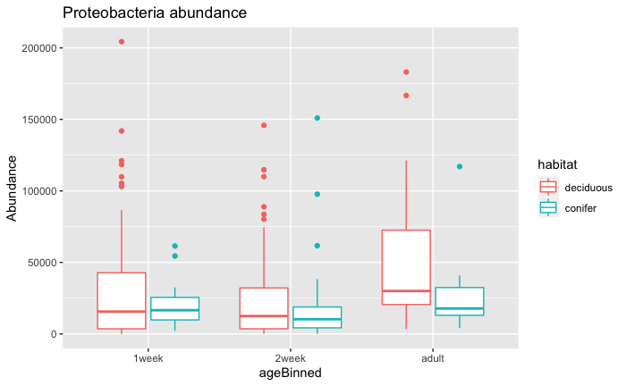

```r
ggplot(proteobacteria.df, aes(ageBinned, Abundance, color=habitat)) +
  geom_boxplot() +
 # geom_jitter(width = 0.2) +
  ggtitle("Proteobacteria abundance")
```

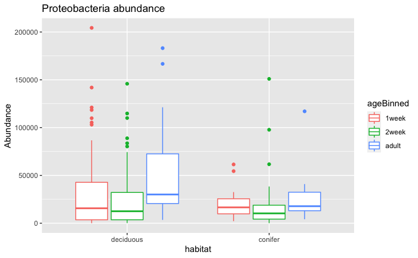

```r
ggplot(proteobacteria.df, aes(habitat, Abundance, color=ageBinned)) +
  geom_boxplot() +
 # geom_jitter(width = 0.2) +
  ggtitle("Proteobacteria abundance")
```

```r
my.backward.diff = matrix(c(-2/3, 1/3, 1/3, -1/3, -1/3, 2/3), ncol = 2)
my.backward.diff
```

```
           [,1]       [,2]
[1,] -0.6666667 -0.3333333
[2,]  0.3333333 -0.3333333
[3,]  0.3333333  0.6666667
```

```r
levels(proteobacteria.df$ageBinned) # verify: 1week,2week,adult
```

```
[1] "1week" "2week" "adult"
```

```r
#assigning the backward difference coding to ageBinned
contrasts(proteobacteria.df$ageBinned) = my.backward.diff
```

Global and specific models the same, as indicated by AIC

```r
binomial.response <- cbind(proteobacteria.df$Abundance,proteobacteria.df$NumberOfReads-proteobacteria.df$Abundance)

all.proteo.global.select <- glmer(binomial.response ~  ageBinned * habitat * layDateFirst + ageBinned * broodSizeWhenSampled + habitat*DistanceToEdge +  (1|site/nest/bird.ID) + (1|SequencePlate), family= binomial, data = proteobacteria.df)

summary(all.proteo.global.select)
```

```
Generalized linear mixed model fit by maximum likelihood (Laplace Approximation) ['glmerMod']
 Family: binomial  ( logit )
Formula: binomial.response ~ ageBinned * habitat * layDateFirst + ageBinned *
    broodSizeWhenSampled + habitat * DistanceToEdge + (1 | site/nest/bird.ID) +      (1 | SequencePlate)
   Data: proteobacteria.df

      AIC       BIC    logLik  deviance  df.resid
 548363.3  548436.9 -274160.7  548321.3       225

Scaled residuals:
     Min       1Q   Median       3Q      Max
-254.918   -0.018    0.000    0.008  159.666

Random effects:
 Groups              Name        Variance Std.Dev.
 bird.ID:(nest:site) (Intercept) 2.8934   1.7010
 nest:site           (Intercept) 1.1574   1.0758
 site                (Intercept) 0.5263   0.7255
 SequencePlate       (Intercept) 1.3622   1.1671
Number of obs: 246, groups:  bird.ID:(nest:site), 197; nest:site, 61; site, 9; SequencePlate, 5

Fixed effects:
                                        Estimate Std. Error  z value Pr(>|z|)
(Intercept)                             0.129672   0.660795    0.196  0.84442
ageBinned1                             -1.631645   0.005248 -310.909  < 2e-16 ***
ageBinned2                              2.808814   0.339305    8.278  < 2e-16 ***
habitatconifer                          0.029551   0.767701    0.038  0.96929
layDateFirst                            0.322579   0.226736    1.423  0.15482
broodSizeWhenSampled                   -0.297646   0.100464   -2.963  0.00305 **
DistanceToEdge                          0.413695   0.230997    1.791  0.07331 .
ageBinned1:habitatconifer               0.795793   0.006990  113.843  < 2e-16 ***
ageBinned2:habitatconifer              -1.726435   0.920542   -1.875  0.06073 .
ageBinned1:layDateFirst                 0.804098   0.002803  286.824  < 2e-16 ***
ageBinned2:layDateFirst                 0.504765   0.388018    1.301  0.19330
habitatconifer:layDateFirst            -0.109813   0.870821   -0.126  0.89965
ageBinned1:broodSizeWhenSampled        -0.722303   0.003251 -222.191  < 2e-16 ***
ageBinned2:broodSizeWhenSampled         0.988111   0.301327    3.279  0.00104 **
habitatconifer:DistanceToEdge          -0.218861   0.515583   -0.424  0.67121
ageBinned1:habitatconifer:layDateFirst -0.288923   0.007361  -39.251  < 2e-16 ***
ageBinned2:habitatconifer:layDateFirst -0.087778   1.422344   -0.062  0.95079
---
Signif. codes:  0 ‘***’ 0.001 ‘**’ 0.01 ‘*’ 0.05 ‘.’ 0.1 ‘ ’ 1
```

```
Correlation matrix not shown by default, as p = 17 > 12.
Use print(x, correlation=TRUE)  or
    vcov(x)        if you need it
```

Some deviation in residuals but not major (acording to Caroline)

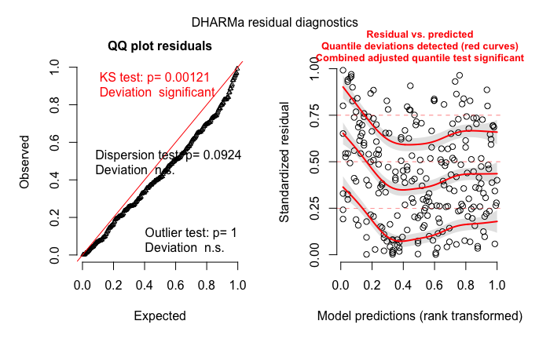

```r
simulationOutput <- simulateResiduals(fittedModel = all.proteo.global.final, n = 10000)
plot(simulationOutput)
```

Plot age*habitat interaction for Proteobacteria model

```r
all.proteo.global.final.effects <- as.data.frame(effect("ageBinned:habitat", all.proteo.global.select))
```

```
NOTE: ageBinned:habitat is not a high-order term in the model
```

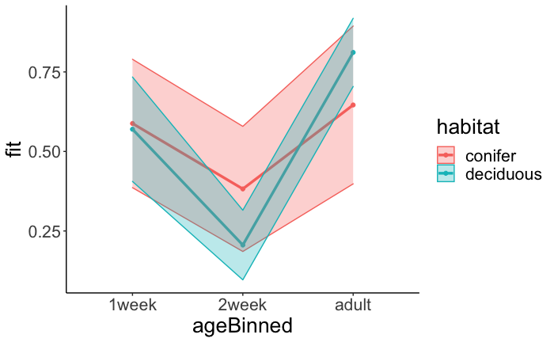

```r
ggplot(all.proteo.global.final.effects, aes(x=ageBinned, y=fit, color=habitat,group=habitat)) +
    geom_point() +
    geom_line(size=1.2) +
    geom_ribbon(aes(ymin=fit-se, ymax=fit+se, fill=habitat),alpha=0.3) +
    theme_classic() + theme(text=element_text(size=20)) #+labs(title = "Reactivity by Daily Control Beliefs", x= "Daily Stressor (0=Did not occur, 1=Occurred)", y="Negative Affect", color="Daily Control Beliefs", fill="Daily Control Beliefs")
```

#All birds Firmicutes

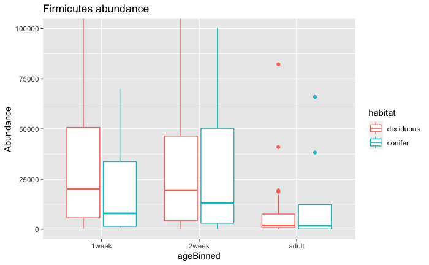

```r
ggplot(firmicutes.df, aes(ageBinned, Abundance, color=habitat)) +
  geom_boxplot() +
  ggtitle("Firmicutes abundance") +
  coord_cartesian(ylim=c(0,100000)) # limits axis without dropping observations
```

```r
levels(firmicutes.df$ageBinned) # verify: 1week,2week,adult
```

```
[1] "1week" "2week" "adult"
```

```r
#assigning the backward difference coding to ageBinned
contrasts(firmicutes.df$ageBinned) = my.backward.diff
```

Global model * WARNING: model nearly unidentifiable, rescale variables * trying different optimizer with more iterations but same problem

```r
binomial.response <- cbind(firmicutes.df$Abundance,firmicutes.df$NumberOfReads-firmicutes.df$Abundance)

all.firmi.global <- glmer(binomial.response ~  ageBinned * habitat * layDateFirst + ageBinned * broodSizeWhenSampled + habitat*DistanceToEdge +  (1|site/nest/bird.ID) + (1|SequencePlate), family= binomial, data = firmicutes.df, glmerControl(optimizer = "bobyqa", optCtrl = list(maxfun = 10000000)))

summary(all.firmi.global)
```

[output not shown]

AIC best model Dropping habitat interaction with distance fixes model WARNING above *final model*

```r
binomial.response <- cbind(firmicutes.df$Abundance,firmicutes.df$NumberOfReads-firmicutes.df$Abundance)

all.firmi.select <- glmer(binomial.response ~  ageBinned * habitat * layDateFirst + ageBinned * broodSizeWhenSampled + DistanceToEdge +  (1|site/nest/bird.ID) + (1|SequencePlate), family= binomial, data = firmicutes.df) # fits well

summary(all.firmi.select)
```

```
Generalized linear mixed model fit by maximum likelihood (Laplace Approximation) ['glmerMod']
 Family: binomial  ( logit )
Formula: binomial.response ~ ageBinned * habitat * layDateFirst + ageBinned *
    broodSizeWhenSampled + DistanceToEdge + (1 | site/nest/bird.ID) +      (1 | SequencePlate)
   Data: firmicutes.df

      AIC       BIC    logLik  deviance  df.resid
 741291.2  741361.3 -370625.6  741251.2       226

Scaled residuals:
     Min       1Q   Median       3Q      Max
-214.026   -0.021    0.001    0.010  276.480

Random effects:
 Groups              Name        Variance Std.Dev.
 bird.ID:(nest:site) (Intercept) 3.5309   1.8791
 nest:site           (Intercept) 2.0702   1.4388
 site                (Intercept) 0.8224   0.9068
 SequencePlate       (Intercept) 1.1993   1.0951
Number of obs: 246, groups:  bird.ID:(nest:site), 197; nest:site, 61; site, 9; SequencePlate, 5

Fixed effects:
                                        Estimate Std. Error  z value Pr(>|z|)
(Intercept)                            -2.114773   0.710959   -2.975  0.00293 **
ageBinned1                              1.631553   0.005022  324.852  < 2e-16 ***
ageBinned2                             -3.273550   0.382138   -8.566  < 2e-16 ***
habitatconifer                          0.099297   0.956591    0.104  0.91733
layDateFirst                           -0.260550   0.282345   -0.923  0.35611
broodSizeWhenSampled                    0.425223   0.115430    3.684  0.00023 ***
DistanceToEdge                          0.062205   0.252674    0.246  0.80554
ageBinned1:habitatconifer              -1.832069   0.006450 -284.055  < 2e-16 ***
ageBinned2:habitatconifer               1.762697   1.008399    1.748  0.08046 .
ageBinned1:layDateFirst                -0.711512   0.002691 -264.422  < 2e-16 ***
ageBinned2:layDateFirst                -0.389537   0.430953   -0.904  0.36605
habitatconifer:layDateFirst             0.488077   0.932063    0.524  0.60052
ageBinned1:broodSizeWhenSampled         0.833245   0.003011  276.697  < 2e-16 ***
ageBinned2:broodSizeWhenSampled        -0.649665   0.346233   -1.876  0.06060 .
ageBinned1:habitatconifer:layDateFirst  0.153300   0.006606   23.208  < 2e-16 ***
ageBinned2:habitatconifer:layDateFirst  0.999520   1.504157    0.665  0.50637
---
Signif. codes:  0 ‘***’ 0.001 ‘**’ 0.01 ‘*’ 0.05 ‘.’ 0.1 ‘ ’ 1
```

```
Correlation matrix not shown by default, as p = 16 > 12.
Use print(x, correlation=TRUE)  or
    vcov(x)        if you need it
```

Residuals non-random but not terrible

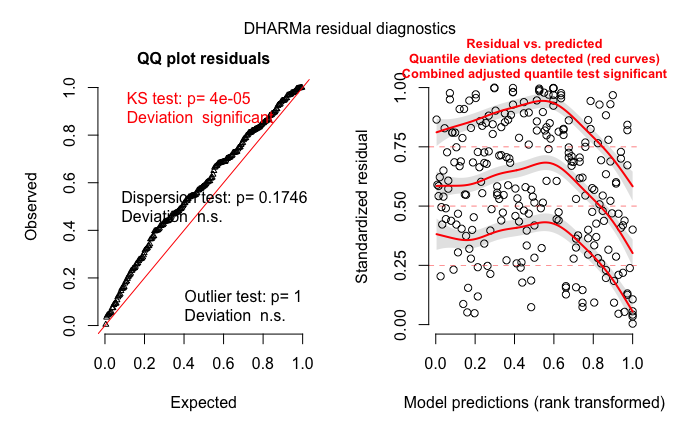

```r
simulationOutput <- simulateResiduals(fittedModel = all.firmi.select, n = 10000)
plot(simulationOutput)
```

```r
all.firmi.select.effects <- as.data.frame(effect("ageBinned:habitat", all.firmi.select))
```

```
NOTE: ageBinned:habitat is not a high-order term in the model
```

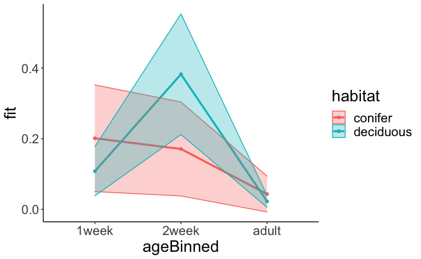

```r
ggplot(all.firmi.select.effects, aes(x=ageBinned, y=fit, color=habitat,group=habitat)) +
    geom_point() +
    geom_line(size=1.2) +
    geom_ribbon(aes(ymin=fit-se, ymax=fit+se, fill=habitat),alpha=0.3) +
    theme_classic() + theme(text=element_text(size=20)) #+labs(title = "Reactivity by Daily Control Beliefs", x= "Daily Stressor (0=Did not occur, 1=Occurred)", y="Negative Affect", color="Daily Control Beliefs", fill="Daily Control Beliefs")
```

# Adult birds Proteobacteria

Full model (mirror of alpha-div model)

```r
#proteobacteria.df.adult <- proteobacteria.df.adult[!proteobacteria.df.adult$BIOM.ID=="SP7M.S10",] # extreme outlier for distance
binomial.response <- cbind(proteobacteria.df.adult$Abundance,proteobacteria.df.adult$NumberOfReads-proteobacteria.df.adult$Abundance)

adult.proteobacteria.global <- glmer(binomial.response ~ Sex * habitat * broodSizeWhenSampled + habitat * layDateFirst * Sex + habitat * DistanceToEdge + (1|site/nest) + (1|SequencePlate), family= binomial, data = proteobacteria.df.adult)

summary(adult.proteobacteria.global)
```

```
Generalized linear mixed model fit by maximum likelihood (Laplace Approximation) ['glmerMod']
 Family: binomial  ( logit )
Formula: binomial.response ~ Sex * habitat * broodSizeWhenSampled + habitat *      layDateFirst * Sex + habitat * DistanceToEdge + (1 | site/nest) +
    (1 | SequencePlate)
   Data: proteobacteria.df.adult

     AIC      BIC   logLik deviance df.resid
 90075.6  90108.5 -45020.8  90041.6       34

Scaled residuals:
     Min       1Q   Median       3Q      Max
-126.091   -0.008    0.000    0.032  204.155

Random effects:
 Groups        Name        Variance Std.Dev.
 nest:site     (Intercept) 2.68173  1.6376
 site          (Intercept) 0.05753  0.2399
 SequencePlate (Intercept) 0.20628  0.4542
Number of obs: 51, groups:  nest:site, 38; site, 8; SequencePlate, 4

Fixed effects:
                                          Estimate Std. Error z value Pr(>|z|)
(Intercept)                               1.334735   0.392133   3.404 0.000665 ***
SexM                                      0.147735   0.006001  24.617  < 2e-16 ***
habitatconifer                           -2.495501   1.780417  -1.402 0.161023
broodSizeWhenSampled                     -1.253916   0.039655 -31.621  < 2e-16 ***
layDateFirst                             -0.036134   0.338202  -0.107 0.914915
DistanceToEdge                           -0.284627   0.296239  -0.961 0.336653
SexM:habitatconifer                       1.934772   2.176004   0.889 0.373928
SexM:broodSizeWhenSampled                 2.095916   0.011824 177.252  < 2e-16 ***
habitatconifer:broodSizeWhenSampled      -3.476188   1.782767  -1.950 0.051190 .
habitatconifer:layDateFirst              -0.724849   2.824488  -0.257 0.797464
SexM:layDateFirst                         0.910679   0.009859  92.370  < 2e-16 ***
habitatconifer:DistanceToEdge             0.370248   1.043900   0.355 0.722831
SexM:habitatconifer:broodSizeWhenSampled  2.496927   1.555771   1.605 0.108506
SexM:habitatconifer:layDateFirst          0.574086   1.988764   0.289 0.772838
---
Signif. codes:  0 ‘***’ 0.001 ‘**’ 0.01 ‘*’ 0.05 ‘.’ 0.1 ‘ ’ 1
```

```
Correlation matrix not shown by default, as p = 14 > 12.
Use print(x, correlation=TRUE)  or
    vcov(x)        if you need it
```

```r
simOut <- simulateResiduals(adult.proteobacteria.global, n = 1000)
plot(simOut)
```

[output not shown]

Adult proteobacteria select Drop distance term from adu.pro.2 (AIC 90071.7) as non-significant in fixed and interaction terms * AIC drops by 2.9 *final model*

```r
#proteobacteria.df.adult <- proteobacteria.df.adult[!proteobacteria.df.adult$BIOM.ID=="SP7M.S10",] # extreme outlier for distance
binomial.response <- cbind(proteobacteria.df.adult$Abundance,proteobacteria.df.adult$NumberOfReads-proteobacteria.df.adult$Abundance)

adult.proteobacteria.select <- glmer(binomial.response ~ Sex * habitat * broodSizeWhenSampled + layDateFirst * Sex + (1|site/nest) + (1|SequencePlate), family= binomial, data = proteobacteria.df.adult)

summary(adult.proteobacteria.select)
```

```
Generalized linear mixed model fit by maximum likelihood (Laplace Approximation) ['glmerMod']
 Family: binomial  ( logit )
Formula: binomial.response ~ Sex * habitat * broodSizeWhenSampled + layDateFirst *      Sex + (1 | site/nest) + (1 | SequencePlate)
   Data: proteobacteria.df.adult

     AIC      BIC   logLik deviance df.resid
 90068.8  90093.9 -45021.4  90042.8       38

Scaled residuals:
     Min       1Q   Median       3Q      Max
-126.097   -0.008   -0.001    0.032  204.154

Random effects:
 Groups        Name        Variance Std.Dev.
 nest:site     (Intercept) 2.7220   1.6498
 site          (Intercept) 0.1089   0.3300
 SequencePlate (Intercept) 0.2077   0.4557
Number of obs: 51, groups:  nest:site, 38; site, 8; SequencePlate, 4

Fixed effects:
                                          Estimate Std. Error z value Pr(>|z|)
(Intercept)                               1.322251   0.408082   3.240  0.00119 **
SexM                                      0.147733   0.006001  24.616  < 2e-16 ***
habitatconifer                           -2.017935   0.976933  -2.066  0.03887 *
broodSizeWhenSampled                     -1.253755   0.039658 -31.614  < 2e-16 ***
layDateFirst                              0.005423   0.327864   0.017  0.98680
SexM:habitatconifer                       1.303328   0.428926   3.039  0.00238 **
SexM:broodSizeWhenSampled                 2.095944   0.011825 177.244  < 2e-16 ***
habitatconifer:broodSizeWhenSampled      -3.083752   1.274551  -2.419  0.01554 *
SexM:layDateFirst                         0.910697   0.009859  92.373  < 2e-16 ***
SexM:habitatconifer:broodSizeWhenSampled  2.316803   1.463388   1.583  0.11338
---
Signif. codes:  0 ‘***’ 0.001 ‘**’ 0.01 ‘*’ 0.05 ‘.’ 0.1 ‘ ’ 1

Correlation of Fixed Effects:
            (Intr) SexM   hbttcn brdSWS lyDtFr SxM:hb SM:SWS hb:SWS SxM:DF
SexM        -0.003
habitatcnfr -0.296  0.002
brdSzWhnSmp -0.009  0.048  0.005
layDateFrst -0.085 -0.007  0.139  0.017
SxM:hbttcnf -0.002 -0.006 -0.593 -0.004 -0.053
SxM:brdSzWS -0.006 -0.028  0.002  0.488  0.003  0.002
hbttcnf:SWS -0.004 -0.002  0.393 -0.032  0.125 -0.855 -0.016
SxM:lyDtFrs  0.000  0.329 -0.003 -0.234 -0.022  0.019  0.016  0.005
SxM:hbt:SWS -0.002  0.001 -0.593 -0.002 -0.052  0.999 -0.007 -0.855  0.000
```

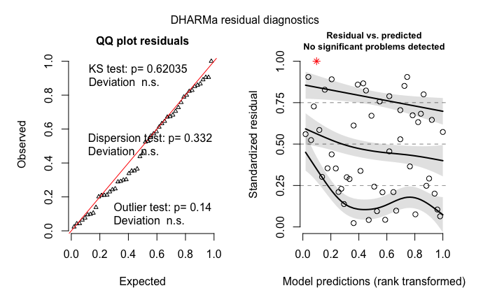

```r
simOut <- simulateResiduals(adult.proteobacteria.select, n = 1000)
plot(simOut)
```

# Adult birds firmicutes

Global adult firmicutes * residuals poor * final variable list, transform to improve residuals?

```r
#firmicutes.df.adult <- subset(firmicutes.df.adult, !BIOM.ID=="SP7M.S10")
binomial.response <- cbind(firmicutes.df.adult$Abundance,firmicutes.df.adult$NumberOfReads-firmicutes.df.adult$Abundance)

adult.firmicutes.global.final <- glmer(binomial.response ~  Sex * habitat * broodSizeWhenSampled + habitat * layDateFirst * Sex + habitat * DistanceToEdge + (1|site/nest) + (1|SequencePlate), family= binomial, data = firmicutes.df.adult, control=glmerControl(optCtrl=list(maxfun=200000)))

summary(adult.firmicutes.global.final)
```

[output not shown]

```r
simOut <- simulateResiduals(adu.fir.1, n = 1000)
plot(simOut)
```

[output not shown]